# DA 101 Lec 11

Your Name

10 October, 2019

## Linear Regression

The idea is simple: sometimes we see patterns in our data. What if it’s a line? Let’s study that.

Note that this technique -only- works for numerical variables. No categoricals here!

Intro exmaple: `mpg`

```r
mpg %>% head
```

| manufacturer | model | displ | year | cyl | trans | drv | cty | hwy | fl | class |
| --- | --- | --- | --- | --- | --- | --- | --- | --- | --- | --- |
| audi | a4 | 1.8 | 1999 | 4 | auto(l5) | f | 18 | 29 | p | compact |
| audi | a4 | 1.8 | 1999 | 4 | manual(m5) | f | 21 | 29 | p | compact |
| audi | a4 | 2.0 | 2008 | 4 | manual(m6) | f | 20 | 31 | p | compact |
| audi | a4 | 2.0 | 2008 | 4 | auto(av) | f | 21 | 30 | p | compact |
| audi | a4 | 2.8 | 1999 | 6 | auto(l5) | f | 16 | 26 | p | compact |
| audi | a4 | 2.8 | 1999 | 6 | manual(m5) | f | 18 | 26 | p | compact |

Observation: cty and hwy might be related. Let’s look! Step 1 in this process is *always* to look at the scatterplot (`geom_point()`)

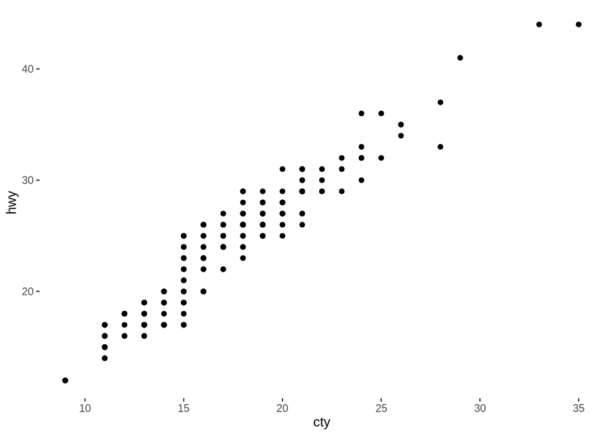

```r
mpg %>% ggplot(aes(x=cty, y=hwy))+geom_point()
```

Whenever we look at a scatterplot, we care about three things:

1. Form. Here, clearly a linear relationship. In DA 101, we focus in linear only, but there are other kinds: logistic, exponential, polynomial, etc.
2. Direction. Here, we have a positive relationship: both variables increase together. In a neg rel, if one increases, the other decreases. In above, it makes sense: if a car is more efficient in the city, I’d expect it to be more efficient on the highway.
3. Strength! You’re all imagining the line, because you’re humans and you see patterns (even they’re not there!). The above seems quite strong. But, not always true. Example:

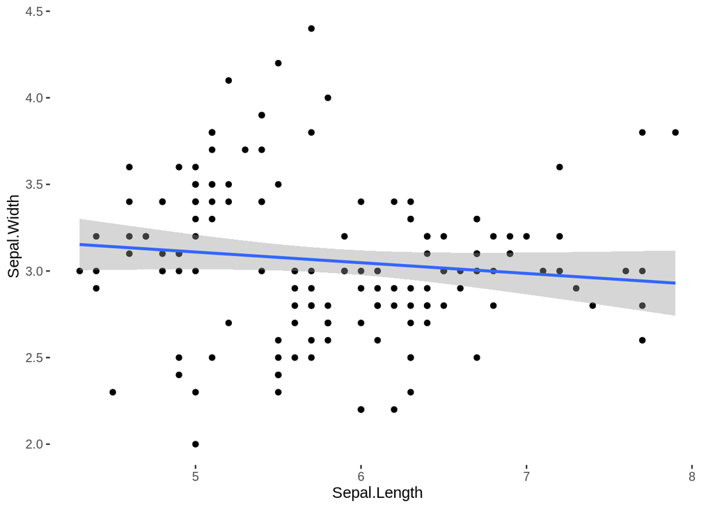

```r
iris %>% ggplot(aes(x=Sepal.Length, y=Sepal.Width))+geom_point()+geom_smooth(method = "lm")
```

The above is very weak, almost non-linear!

Our goal: understand these relationships, their properties, and how strong they are!

### The Correlation Coefficient r

We need a measurement of how strong linear relationships are. It’s called “r”, not to be confused with R, our software.

Our convention:

R = our languange/software r = the correlation coefficient

Finding r in R is easy! Use `cor`

For mpg:

```r
cor(mpg$cty, mpg$hwy)
```

```
## [1] 0.9559159
```

How to interpret this?

Key points:

- Close to +/- 1, then stronger.
- Close to zero means no linear relationship.

#### In-class challenge

Make a scatterplot of cty mpg vs displ (displacement is the size of the engine). Compute its correlation coefficient, and interpret: does this all make sense?

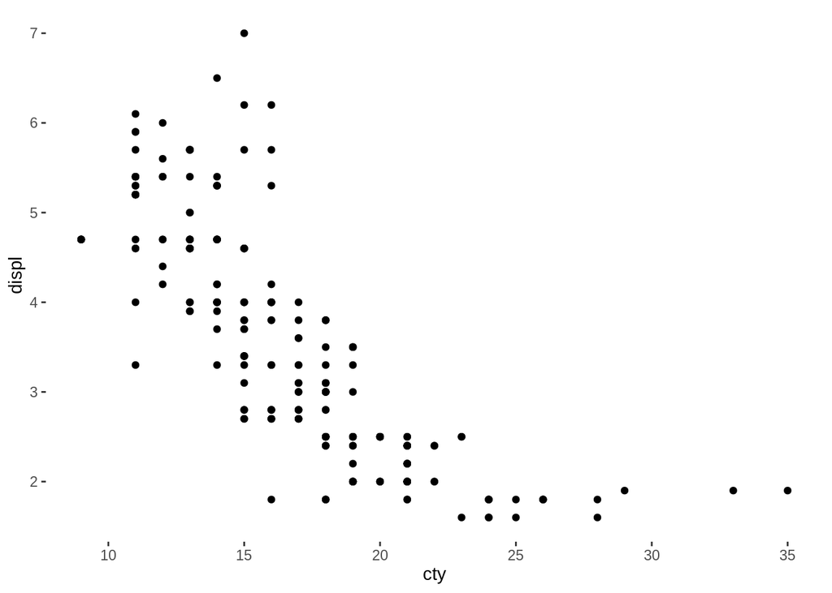

```r
# cty vs displ

mpg %>% ggplot(aes(x=cty, y=displ))+geom_point()
```

```r
cor(mpg$cty, mpg$displ)
```

```
## [1] -0.798524
```

Let’s interpret:

Form: Linear model is reasonable. Maybe other options too. Direction: Negative Strength: Moderate to strong

Note, this makes perfect sense! If the car gets bigger, I’d expect it’s efficiency to be lower. I.e., a big truck needs more gas than a little Honda Civic.